# Assingment#2

Jay

February 12, 2018

# A Glimplse Of Violent Crimes in the United States

In this Assignment, I have used FBI crime data for the year 2014 (Courtesy of Social Explorer), to analyze the patterns of four types of major crime in the US mainly: Murder, Rape, Robbery, and Aggravated Assault. This data is yearly published by FBI, under the Uniform Crime Reporting (UCR) Program, and has been the starting place for law enforcement executives, students of criminal justice, researchers, members of the media, and the public at large seeking information on crime in the nation.

The program was conceived in 1929 by the International Association of Chiefs of Police to meet the need for reliable uniform crime statistics for the nation. In 1930, the FBI was tasked with collecting, publishing, and archiving those statistics The data presented in Crime in the United States reflect the Hierarchy Rule, which requires that only the most serious offense in a multiple-offense criminal incident be counted, that is why we have four serious offences included in our data set.

# SOURCE: (https://ucr.fbi.gov/crime-in-the-u.s/2014/crime-in-the-u.s.-2014/offenses-known-to-law-enforcement/violent-crime)

# Libraries used in this Assingment:-

```r
library(haven)
library(dplyr)
library(tibble)
```

```r
library(mosaic)
```

```
## 'data.frame':    51 obs. of  8 variables:
##  $ FIPS                : int  1 2 4 5 6 8 9 10 11 12 ...
##  $ Name.of.Area        : Factor w/ 51 levels "Alabama","Alaska",..: 1 2 3 4 5 6 7 8 9 10 ...
##  $ Qualifying.Name     : Factor w/ 51 levels "Alabama","Alaska",..: 1 2 3 4 5 6 7 8 9 10 ...
##  $ Total.Violent.Crimes: int  20100 4657 25898 13434 151564 16320 8575 4569 8199 91065 ...
##  $ Murders             : int  270 41 305 166 1700 148 89 50 105 981 ...
##  $ Rapes               : int  1935 765 3176 1686 9399 3050 794 390 472 7104 ...
##  $ Robberies           : int  4584 627 6176 1897 48674 3025 3172 1271 3497 21576 ...
##  $ Aggravated.Assaults : int  13302 3224 16240 9684 91791 10095 4520 2857 4125 61404 ...
```

```
## [1] "FIPS"                 "Name.of.Area"         "Qualifying.Name"
## [4] "Total.Violent.Crimes" "Murders"              "Rapes"
## [7] "Robberies"            "Aggravated.Assaults"
```

```
##       FIPS           Name.of.Area   Qualifying.Name Total.Violent.Crimes
##  Min.   : 1.00   Alabama   : 1    Alabama   : 1     Min.   :   637
##  1st Qu.:16.50   Alaska    : 1    Alaska    : 1     1st Qu.:  5124
##  Median :29.00   Arizona   : 1    Arizona   : 1     Median : 16049
##  Mean   :28.96   Arkansas  : 1    Arkansas  : 1     Mean   : 22848
##  3rd Qu.:41.50   California: 1    California: 1     3rd Qu.: 26223
##  Max.   :56.00   Colorado  : 1    Colorado  : 1     Max.   :151564
##                  (Other)   :45    (Other)   :45
##     Murders           Rapes           Robberies     Aggravated.Assaults
##  Min.   :  10.0   Min.   :  117.0   Min.   :   53   Min.   :  439
##  1st Qu.:  55.5   1st Qu.:  592.5   1st Qu.: 1039   1st Qu.: 3182
##  Median : 157.0   Median : 1428.0   Median : 3497   Median : 9684
##  Mean   : 274.0   Mean   : 2134.9   Mean   : 6278   Mean   :14159
##  3rd Qu.: 365.5   3rd Qu.: 2408.0   3rd Qu.: 6952   3rd Qu.:17059
##  Max.   :1700.0   Max.   :11583.0   Max.   :48674   Max.   :91791
##
```

```r
glimpse(CrimeData)
```

```
## Observations: 51
## Variables: 8
## $ FIPS                 <int> 1, 2, 4, 5, 6, 8, 9, 10, 11, 12, 13, 15, ...
## $ Name.of.Area         <fct> Alabama, Alaska, Arizona, Arkansas, Calif...
## $ Qualifying.Name      <fct> Alabama, Alaska, Arizona, Arkansas, Calif...
## $ Total.Violent.Crimes <int> 20100, 4657, 25898, 13434, 151564, 16320,...
## $ Murders              <int> 270, 41, 305, 166, 1700, 148, 89, 50, 105...
## $ Rapes                <int> 1935, 765, 3176, 1686, 9399, 3050, 794, 3...
## $ Robberies            <int> 4584, 627, 6176, 1897, 48674, 3025, 3172,...
## $ Aggravated.Assaults  <int> 13302, 3224, 16240, 9684, 91791, 10095, 4...
```

```r
CrimeData %>%
  select(Name.of.Area, Murders, Rapes, Robberies, Aggravated.Assaults)%>%
  arrange(Name.of.Area)%>%
  head(CrimeData, n=51L)
```

```
##            Name.of.Area Murders Rapes Robberies Aggravated.Assaults
## 1               Alabama     270  1935      4584               13302
## 2                Alaska      41   765       627                3224
## 3               Arizona     305  3176      6176               16240
## 4              Arkansas     166  1686      1897                9684
## 5            California    1700  9399     48674               91791
## 6              Colorado     148  3050      3025               10095
## 7           Connecticut      89   794      3172                4520
## 8              Delaware      50   390      1271                2857
## 9  District of Columbia     105   472      3497                4125
## 10              Florida     981  7104     21576               61404
## 11              Georgia     602  2200     12783               22458
## 12               Hawaii      30   464       952                1842
## 13                Idaho      32   632       202                2553
## 14             Illinois     683  4173     15112               26965
```

[output cut: 37 more lines]

```r
lowmurder_states <-filter(CrimeData, Murders < 100)
highmurder_states <- filter(CrimeData, Murders >= 100)
```

# VIOLENT CRIME INCIDENTS FOR FOUR SPECIFIC STATES.

```r
specific_states <- filter(CrimeData, Name.of.Area == "New York" | Name.of.Area == "Florida" | Name.of.Area == "California" | Name.of.Area == "Texas" )
specific_states %>%
    select(Name.of.Area, Total.Violent.Crimes)%>%
    arrange(desc(Total.Violent.Crimes))%>%
    head(specific_states, n=5)
```

```
##   Name.of.Area Total.Violent.Crimes
## 1   California               151564
## 2        Texas               109393
## 3      Florida                91065
## 4     New York                75865
```

# STATES WITH LOWEST VIOLENT CRIME INCIDENTS.

```r
CrimeData %>%
    select(Name.of.Area, Murders, Rapes, Robberies, Aggravated.Assaults)%>%
    arrange(desc(Murders))%>%
    filter(Murders <20 | Rapes <50 | Robberies <100 | Aggravated.Assaults <200)%>%
    head(specific_states, n=5)
```

```
##    Name.of.Area Murders Rapes Robberies Aggravated.Assaults
## 1 New Hampshire      16   553       526                1401
## 2       Wyoming      16   165        53                 872
## 3       Vermont      10   117        71                 439
```

```r
specific_variables <- select(CrimeData, Name.of.Area, Total.Violent.Crimes  )
```

# CREATING A NEW VARIBLE

Using the the UCR’s Total violent crime data, we will create a varible for crime rate. The crime rate variable basically gives us a number of crime(s) occured per 100,000 population. THis is simply done by: Dividing Total Number of Crimes by the total of Population of the US and Multiplying with 100,000. This will help us to take a look at STATES with higer crime rates.

# We also created 4 additional variable to calcualte each percentage of each type of crime in the particular state.

```r
Regional_Data<- mutate(CrimeData, Crime.Rate = Total.Violent.Crimes/325467306 * 100000, Murder_Percent = Murders/Total.Violent.Crimes * 100, Rapes_Percent = Rapes/Total.Violent.Crimes *100, Robberies_Percent= Robberies/Total.Violent.Crimes *100, AA_Percent= Aggravated.Assaults/Total.Violent.Crimes *100 )
Regional_Data <- arrange(Regional_Data, desc(Murder_Percent))
```

# CRIME RATES OF DIFFERENT STATES (Descending Order)

According to the data: California has been the state with higest crime rate. In California, 46.5 crimes have been reported per 100,000 population, as compare to Texas which has 33.6 crime rate per 100,000 population followed by Florida with a 27.97 rate per 100,000 and New York with 23.30 per 100,000 of population.

```r
Regional_Data %>%
  select(Name.of.Area, Crime.Rate, Murder_Percent, Rapes_Percent, Robberies_Percent, AA_Percent)%>%
  arrange(desc(Crime.Rate))
```

```
##            Name.of.Area Crime.Rate Murder_Percent Rapes_Percent
## 1            California 46.5681183      1.1216384      6.201341
## 2                 Texas 33.6110565      1.0878210     10.588429
## 3               Florida 27.9797689      1.0772525      7.801021
## 4              New York 23.3095609      0.8132868      7.865287
## 5              Illinois 14.4198815      1.4552970      8.891588
## 6              Michigan 12.9816418      1.2875435     14.811484
## 7          Pennsylvania 12.3659118      1.5156409      9.533630
## 8             Tennessee 12.2399391      0.9212541      6.483922
## 9               Georgia 11.6890389      1.5823783      5.782778
## 10                 Ohio  9.6319966      1.4226929     15.107340
## 11       North Carolina  9.6273879      1.5893279      5.463714
## 12             Missouri  8.2545926      1.5037594      8.936946
## 13             Maryland  8.1074196      1.3794672      4.354417
## 14        Massachusetts  8.0066414      0.5065428      7.713266
```

[output cut: 89 more lines]

# CREATING VARIABLE Region USING “mutate”

```r
Regional_Data <- mutate(Regional_Data, Crime.Rate = Crime.Rate, Region = FIPS)
```

# USING “recode”TO CREATE REGIONS BASED ON STATES.

# This recode will help to use to use Region as a categorical variable to identify multiple cases of crime in specific regions in the US.

```r
Regional_Data$Region <- recode (Regional_Data$Region,

'09' = "North East", '23' = "North East", '25' = "North East", '33' = "North East",
'44' = "North East", '50' = "North East",'34' = "North East", '36' = "North East", '42' = "North East",

'17' = "Midwest", '18'= "Midwest",'26'= "Midwest",'39'= "Midwest",'55'= "Midwest", '19' = "Midwest",
'20' = "Midwest", '27' =  "Midwest",'29'= "Midwest", '31' = "Midwest", '38' = "Midwest", '46' = "Midwest",

'10' = "South", '12'= "South",'13'= "South",'24'= "South",'37'= "South", '45' = "South", '51' = "South",
'54' = "South",'01'= "South",'21' = "South",'28' = "South",'47' = "South",'05' = "South", '22' = "South",
'40' = "South", '48' = "South", '11' = "South",

'04' = "West", '08'= "West",'16'= "West",'30'= "West", '32'= "West", '35' = "West", '49' = "West",'56' = "West",
'02'= "West", '06' = "West", '15' = "West", '41' = "West", '53' = "West")
```

```r
str(Regional_Data)
```

```
## 'data.frame':    51 obs. of  14 variables:
##  $ FIPS                : int  28 51 22 37 13 50 21 34 42 29 ...
##  $ Name.of.Area        : Factor w/ 51 levels "Alabama","Alaska",..: 25 47 19 34 11 46 18 31 39 26 ...
##  $ Qualifying.Name     : Factor w/ 51 levels "Alabama","Alaska",..: 25 47 19 34 11 46 18 31 39 26 ...
##  $ Total.Violent.Crimes: int  5482 16523 24172 31334 38044 637 9460 22992 40247 26866 ...
##  $ Murders             : int  181 351 467 498 602 10 147 352 610 404 ...
##  $ Rapes               : int  551 2415 1346 1712 2200 117 1549 951 3837 2401 ...
##  $ Robberies           : int  1825 4293 5625 8232 12783 71 3320 10501 13535 5589 ...
##  $ Aggravated.Assaults : int  2923 9462 16731 20887 22458 439 4422 11185 22265 18468 ...
##  $ Crime.Rate          : num  1.68 5.08 7.43 9.63 11.69 ...
##  $ Murder_Percent      : num  3.3 2.12 1.93 1.59 1.58 ...
##  $ Rapes_Percent       : num  10.05 14.62 5.57 5.46 5.78 ...
##  $ Robberies_Percent   : num  33.3 26 23.3 26.3 33.6 ...
##  $ AA_Percent          : num  53.3 57.3 69.2 66.7 59 ...
##  $ Region              : chr  "South" "South" "South" "South" ...
```

# RECOMMENDED METHODS FOR PIPE FUNCTION : SIMPLING USING MULTIPLE OPERATIONS TOGATHER.

From using the operation above, we have regional based statistics in averages of eact region in the US of reported crimes in 2014. From the table we can see that the average murders in South region is the highest, and lowest in the North East Region.

```r
Regional_Data %>%
  group_by(Region) %>%
  select(Murders, Rapes, Robberies, Aggravated.Assaults) %>%
  summarise(
    avg_murders = mean(Murders, na.rm = TRUE),
    avg_rapes = mean(Rapes, na.rm = TRUE),
    avg_robberies = mean(Robberies, na.rm = TRUE),
    avg_aggravated.assaults = mean(Aggravated.Assaults, na.rm = TRUE))%>%
  arrange(avg_murders)%>%
  filter(avg_murders <= 500)
```

```
## # A tibble: 4 x 5
##   Region     avg_murders avg_rapes avg_robberies avg_aggravated.assaults
##   <chr>            <dbl>     <dbl>         <dbl>                   <dbl>
## 1 North East         208      1665          6518                   11697
## 2 West               223      1984          5927                   13026
## 3 Midwest            240      2236          5012                   11350
## 4 South              372      2427          7314                   18310
```

# ALTERNATIVE METHOD WITHOUT USING PIPE FUCTION.

```r
Regionalgrp_Data <- group_by(Regional_Data, Region)
summary_data <- summarise(Regionalgrp_Data,
                          avg_murders = mean(Murders, na.rm = TRUE),
                          avg_robberies = mean(Robberies, na.rm = TRUE),
                          avg_rapes = mean(Rapes, na.rm = TRUE),
                          avg_totalvcrime = mean(Total.Violent.Crimes, na.rm = TRUE))
```

# DESCRIPTIVE STATISTICS FOR OUR ANALYSIS

The table below shows statistics for our data.

```r
favstats (Murders ~ Region, data = Regionalgrp_Data, na.rm = TRUE)
```

```
##       Region min     Q1 median    Q3  max     mean       sd  n missing
## 1    Midwest  21  57.25    124 414.5  683 240.0000 229.3330 12       0
## 2 North East  10  21.00     89 352.0  617 208.1111 253.4065  9       0
## 3      South  50 166.00    323 467.0 1190 371.7647 312.1453 17       0
## 4       West  16  38.00     79 170.0 1700 223.0769 451.2912 13       0
```

```r
favstats (Rapes ~ Region, data = Regionalgrp_Data, na.rm = TRUE)
```

```
##       Region min   Q1 median   Q3   max     mean       sd  n missing
## 1    Midwest 382 1021 1596.5 2844  6258 2236.500 1859.014 12       0
## 2 North East 117  390  794.0 2010  5967 1665.000 1986.143  9       0
## 3      South 390 1149 1712.0 2200 11583 2427.176 2806.754 17       0
## 4       West 165  632 1220.0 2531  9399 1984.385 2432.680 13       0
```

```r
favstats (Robberies ~ Region, data = Regionalgrp_Data, na.rm = TRUE)
```

```
##       Region min   Q1 median      Q3   max     mean        sd  n missing
## 1    Midwest 175 1040 4370.5  6991.5 15112 5012.000  4865.707 12       0
## 2 North East  71  526 3172.0 10501.0 24020 6517.556  8176.380  9       0
## 3      South 510 3073 4293.0  8232.0 30981 7314.471  7988.217 17       0
## 4       West  53  627 2075.0  5643.0 48674 5927.154 13035.759 13       0
```

```r
favstats (Aggravated.Assaults ~ Region, data = Regionalgrp_Data, na.rm = TRUE)
```

```
##       Region  min   Q1 median    Q3   max     mean        sd  n missing
## 1    Midwest 1418 5336   8340 15018 27437 11350.50  8985.216 12       0
## 2 North East  439 1398   4520 17916 45256 11696.56 14933.055  9       0
## 3      South 2857 4422  13302 20887 65637 18309.71 18646.818 17       0
## 4       West  872 2553   5883 10554 91791 13026.46 24120.644 13       0
```

# AVERAGE MUDERDERS IN THE US. BY REGION

# According to the Data the average muders in South region of the US is around 371.

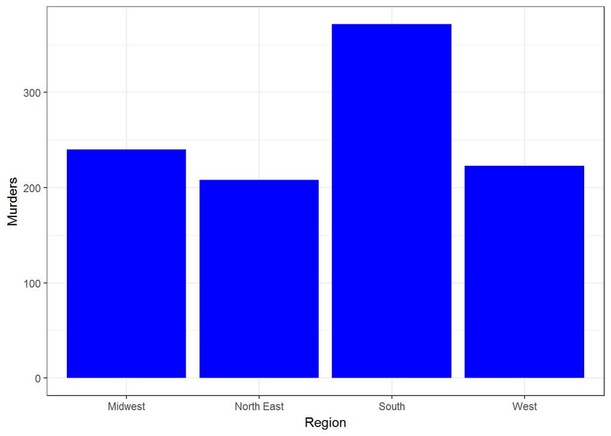

```r
ggplot(Regional_Data, aes(x= Region, y=Murders ))+theme_bw() +geom_bar(stat= "summary", fun.y = "mean", fill="blue")
```